# Text mining : exploration statistique d’un corpus de courriels

```
                    Douaa BENHADDOUCHE - Lilia HARIRECHE - Antoine RODRIGUEZ

                                          MLDS FA
```

# **Partie A: Les données spam.**

## (1) La nature des variables.

```r
spam=read.table("https://www.math.univ-toulouse.fr/~besse/Wikistat/data/spam.dat",header=TRUE)

dim(spam)  # 4601   58
```

```
## [1] 4601   58
```

```r
 # summary(spam)

spam[,1]=as.factor(spam[,1])
```

Les variables sont quantitatives. (voir le pdf) La variable ‘spam’ est binaire : 1 désigne un spam et 0 désigne un mail classique.

## (2) Standardisation

Vu que les variables (sauf spam) sont toutes dissymétriques et comportent beaucoup de “O”, nous devons faire une standardisation de celles-ci.

```r
Lspam=data.frame("spam"=spam[,1],log(1+spam[,2:58]))
```

## (3) Utilisation de Factoshiny

```r
library(Factoshiny)
```

```r
res=Factoshiny(spam)
```

Le rapport automatique de Factoshiny (où la variable spam est supplémentaire) `Rapport_FactoShiny_A_3.html`, nous montre une legère séparation des spams du reste des mails par l’axe de la seconde composante principale. (Peut être plus précisément une séparartion par une droite affine passant par l’origine dans le premier plan factoriel)

## (4) Execution du code du document

### Approche quantitative

```r
library(FactoMineR)
```

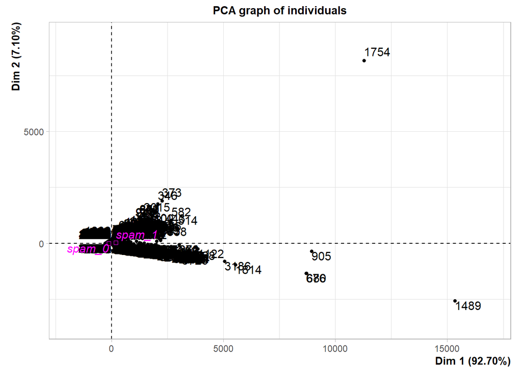

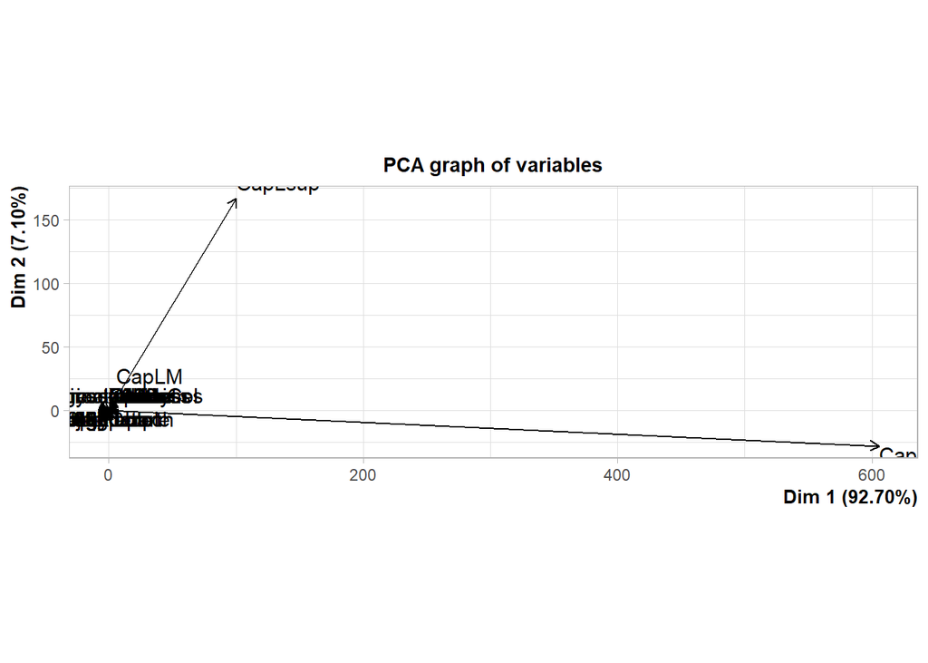

```r
#pca spam
res.pca=PCA(spam,scale.unit = FALSE,quali.sup=1)
```

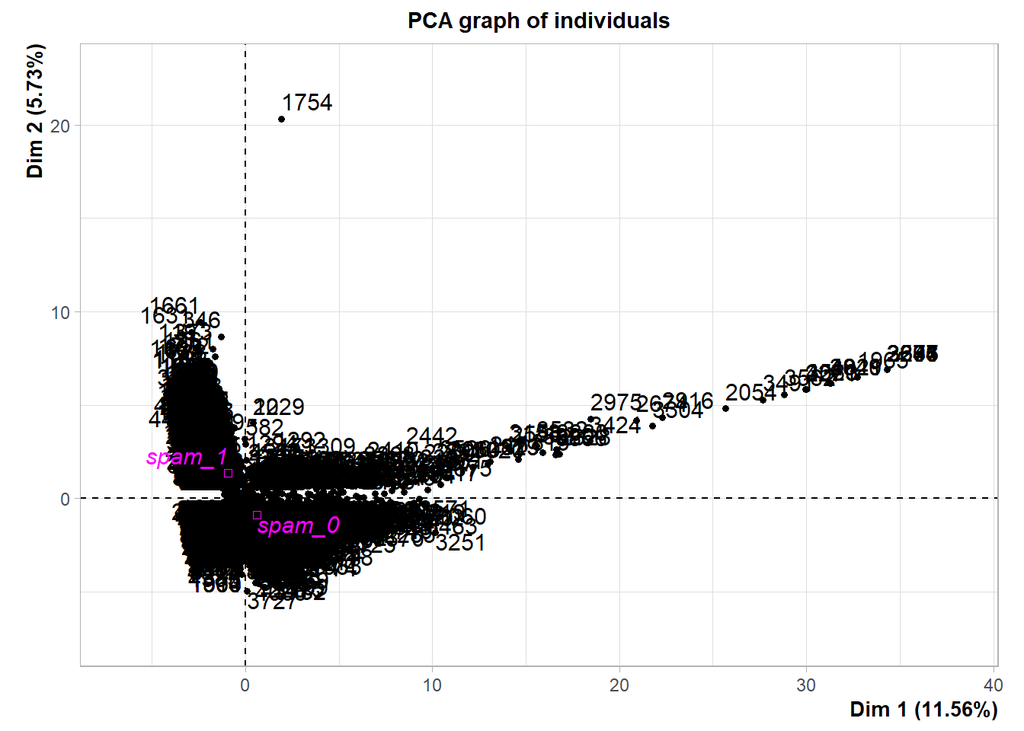

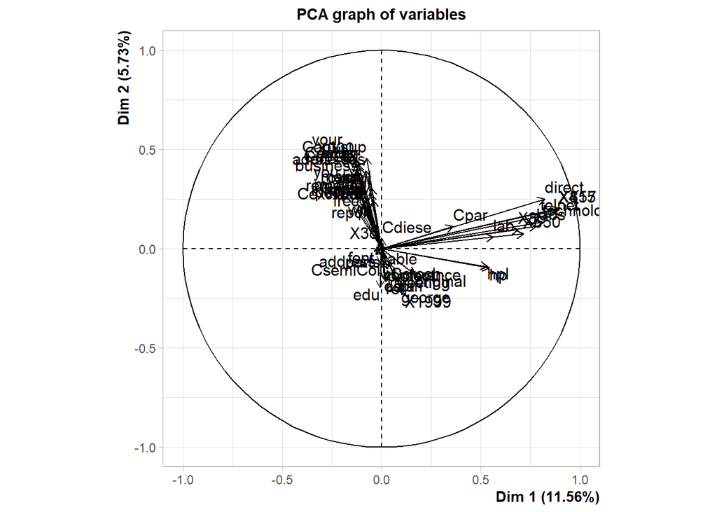

```r
res.pca1=PCA(spam,scale.unit = TRUE,quali.sup=1)
```

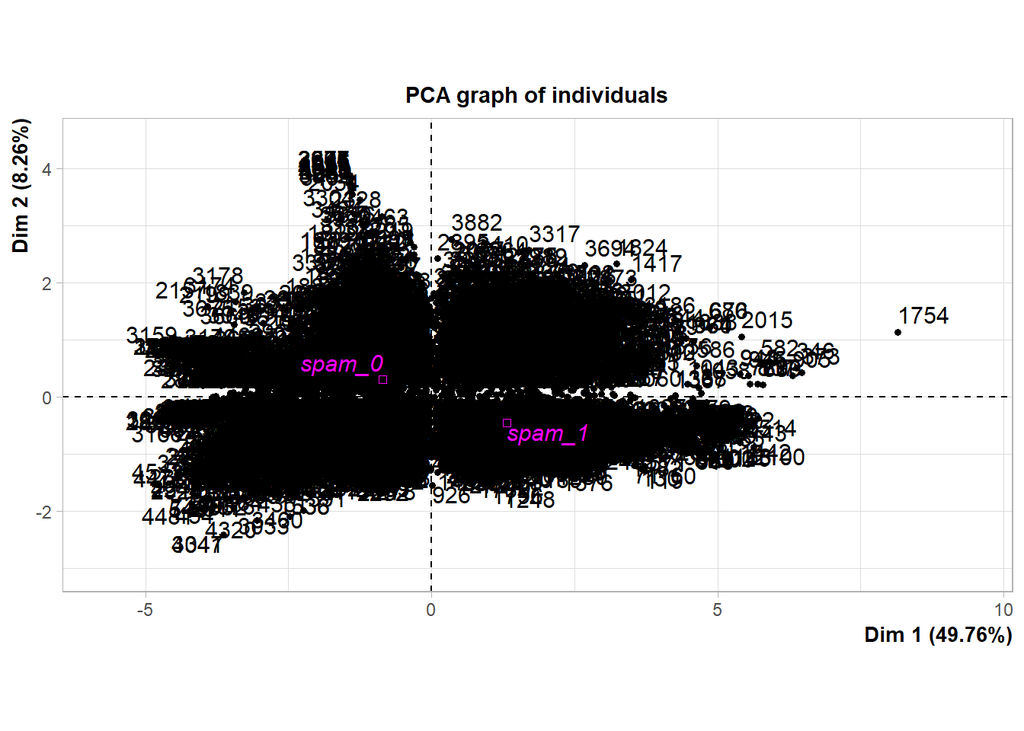

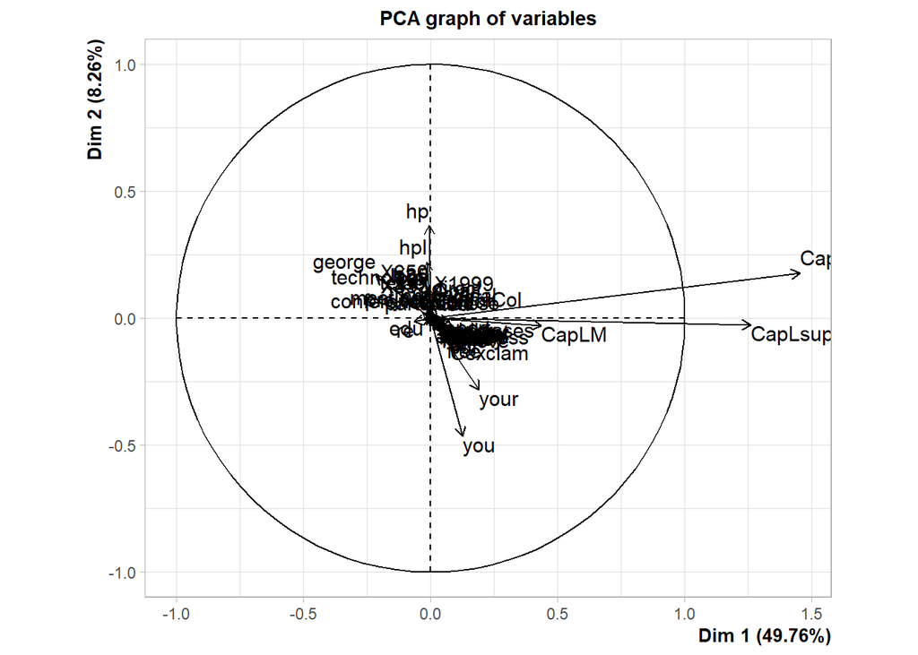

```r
#pca Lspam
res.pca=PCA(Lspam,scale.unit = FALSE, quali.sup=1)
```

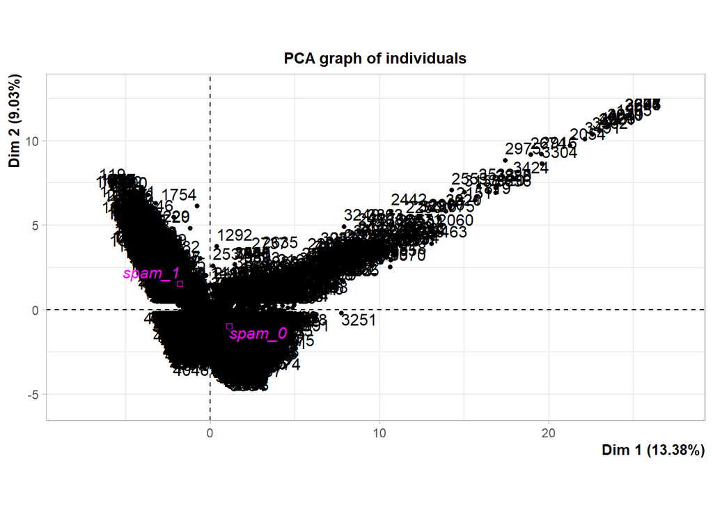

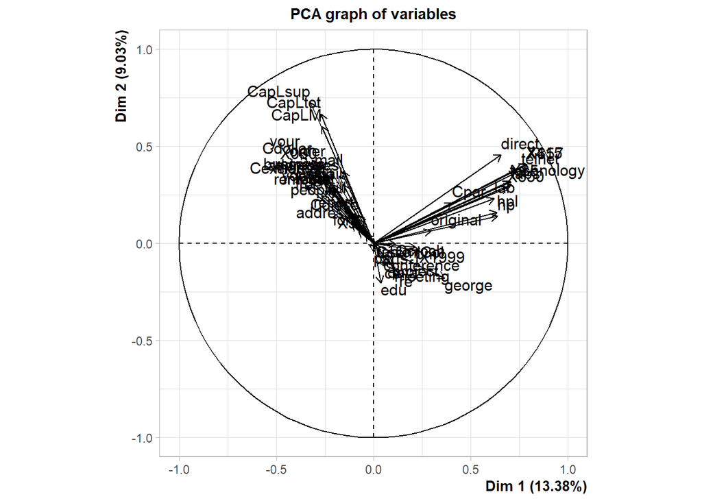

```r
res.pca=PCA(Lspam,scale.unit = TRUE,quali.sup=1)
```

Nous remarquons que l’ACP appliquée sur le jeu de données après *normalisation et standardisation* donne des résultats plus clairs par rapports aux autres. Nous pourrons ainsi distinguer, selon *le graphe des individus*, qu’il existe deux classe, ainsi *le graphe des variables* montre les différentes variables qui contribuent à la création des classes (0) et (1) respectivement.

A cause du nombre de variables, les résultats obtenus ci dessus ne sont pas satisfaisants, donc afin de pouvoir intérpreter les résultats nous allons opté pour la classification des variables.

- *Classification des variables*

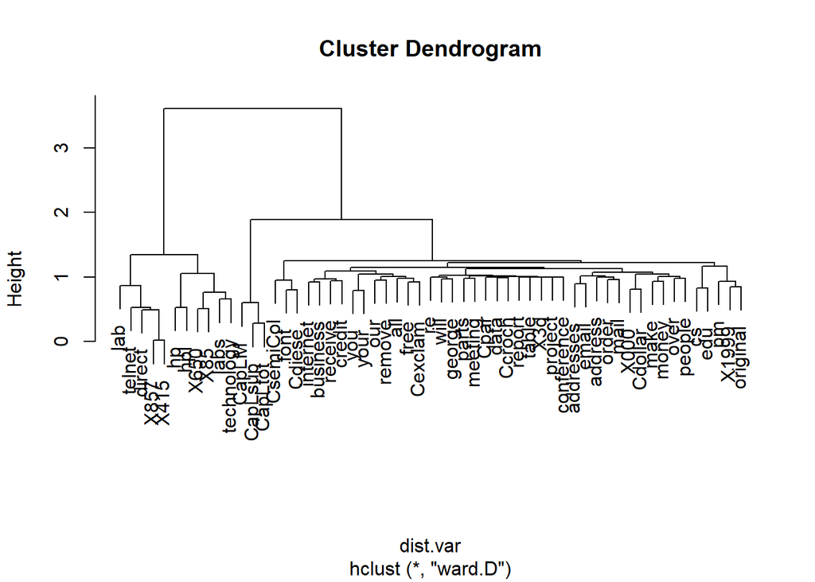

```r
dist.var<-as.dist(1-cor(Lspam[2:58])**2)
clas.var<-hclust(dist.var,method="ward.D")
plot(clas.var)
```

Le dendrogramme ci dessus révéle qu’il y a deux classes de variables, cela est montré aussi dans le graphe des variables obtenu précédemment dans L’ACP où deux groupes de variables sont corrélés par rapport à l’axe1 et l’axe2 respectivement.

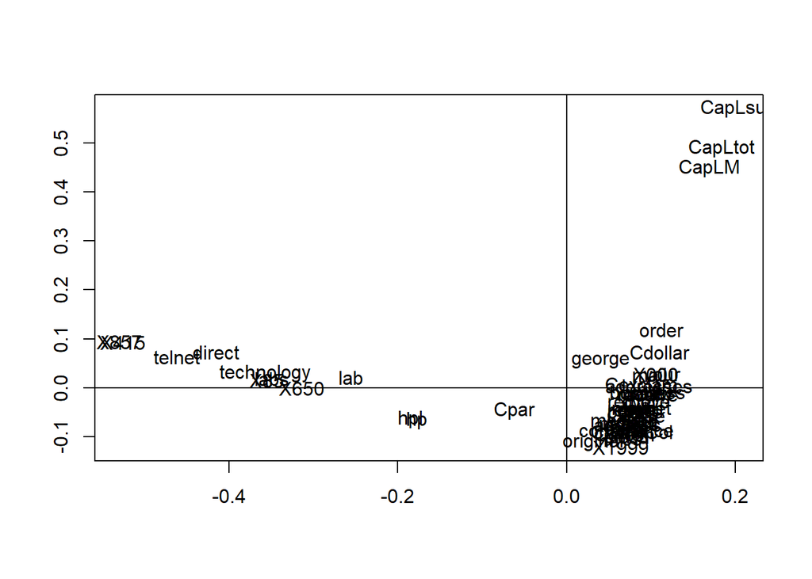

```r
# MDS: Méthode factorielle de réduction de dimension pour l’exploration statistique d’une matrice de distances ou dissemblances entre individus

rS = cor(Lspam[2:58])
dS2=sqrt(1-rS**2)
dN=dimnames(Lspam[2:58])[[2]]
mdspam= cmdscale(dS2, k=2)  # 2 classes
plot(mdspam, type="n", xlab="", ylab="",main="")
text(mdspam,dN)
abline(v=0,h=0)
```

```r
classes <- cutree(clas.var,k=4)   # 4 classes
sort(classes)
```

```
##       make    address        all        X3d        our       over     remove
##          1          1          1          1          1          1          1
##   internet      order       mail    receive       will     people     report
##          1          1          1          1          1          1          1
##  addresses       free   business      email        you     credit       your
##          1          1          1          1          1          1          1
##       font       X000      money     george       data      X1999      parts
##          1          1          1          1          1          1          1
##         pm         cs    meeting   original    project         re        edu
##          1          1          1          1          1          1          1
##      table conference   CsemiCol       Cpar     Ccroch    Cexclam    Cdollar
##          1          1          1          1          1          1          1
##     Cdiese         hp        hpl       X650       labs        X85 technology
##          1          2          2          2          2          2          2
##        lab     telnet       X857       X415     direct      CapLM    CapLsup
##          3          3          3          3          3          4          4
##    CapLtot
##          4
```

```r
names(classes[classes==2]) #variables de la classe 2
```

```
## [1] "hp"         "hpl"        "X650"       "labs"       "X85"
## [6] "technology"
```

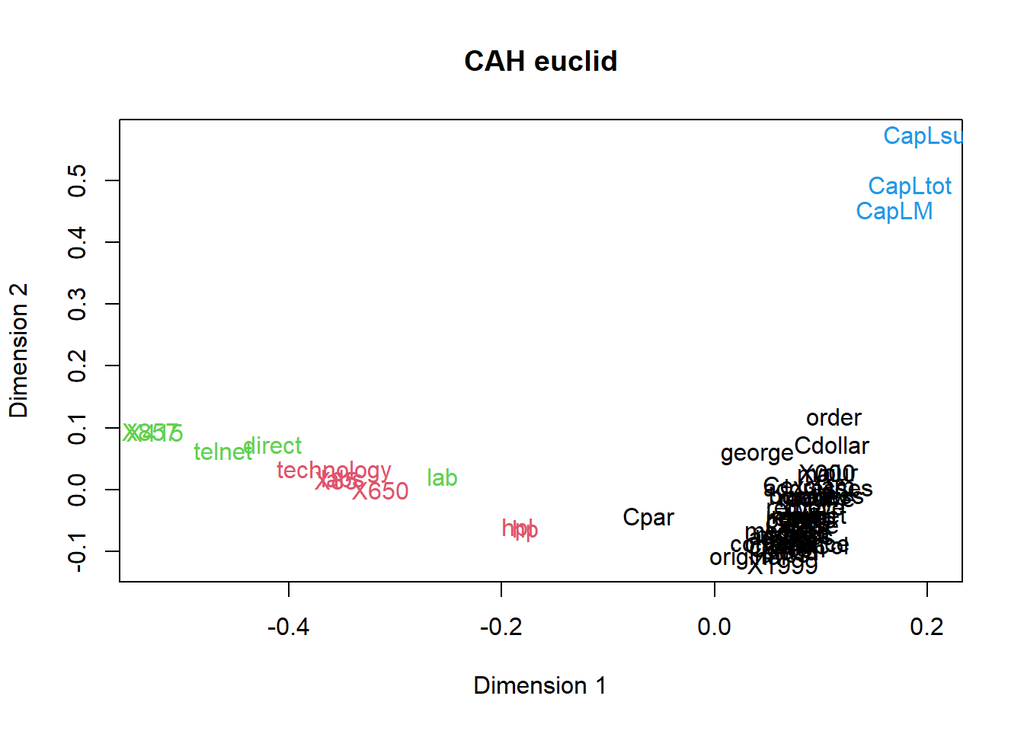

```r
coul = classes
plot(mdspam, type="n", xlab="Dimension 1", ylab="Dimension 2", main="CAH euclid")
text(mdspam,dN,col=coul)
```

### Approche par NMF

Le principe est de rechercher deux matrices de faible rang r de telle sorte que leur produit approche au mieux les valeurs observées. Contrairement à L’ACP où les facteurs sont recherchés orthogonaux 2 à 2, cette méthode impose la contrainte de non négativité des matrices pour construire les facteurs de la décomposition. Ces facteurs ne permettent plus de représentation comme en ACP ou en MDS mais au moins une classification non supervisée tant des lignes que des objets lignes et colonnes de la matrice.

```r
library(NMF)
```

*Problème d’installation du package. Impossibilité de poursuivre*

# **Partie B: La base de données spam brute (SUJET 1)**

## **Chargement des données**

```r
library(R.matlab)
library(FactoMineR)
library(Factoshiny)
library(readr)
library(CoClust)
library(skmeans)
library(caret)
library(tm)
library(aricode)
library(NbClust)
library(Rmixmod)
library(mclust)
library(blockmodels)
library(Rtsne) # pour réduction de dimension t-SNE
library(factoextra) # fviz_pca_ind
library(movMF)
library(blockcluster)

#for plotcluster()
library(cluster)
library(fpc)

# solve_LSAP
library(clue)
```

```r
#Antoine
setwd ('C:/Users/rodri/Desktop/TRAVAUXENCOURS/__Projet_TextMining')
spam<-read.csv('spam.csv')
```

```r
setwd ('E:/M2_MLDS_FA/Texte mining')
spam<-read.csv('spam.csv')
```

## **Prétraitement et préparation des données spam**

Avant d’appliquer un algorithme de classification des données, nous allons tout d’abord faire quelques prétraitements, dont la construction de la matrice DocumentTerm, la suppression des lignes contenant que des zéros, sur la matrice obtenue, ainsi que la binarisation des classes.

```r
data.spam  = spam[,2] #récuperer les mails
length(data.spam)
```

```
## [1] 5572
```

```r
m <- enc2utf8(data.spam)
```

```r
# transform texts to corpus
mails <- Corpus(VectorSource(m))
# replace special characters by space
toSpace <- content_transformer(function (x , pattern ) gsub(pattern, " ", x))
mails <- tm_map(mails, toSpace, "/")
mails <- tm_map(mails, toSpace, "@")
mails <- tm_map(mails, toSpace, "\\|")
```

```r
# corpus cleaning
# lower characters
mails <- tm_map(mails, content_transformer(tolower))
# delete numbers
mails <- tm_map(mails, removeNumbers)
# delete english stopwords
mails <- tm_map(mails, removeWords, stopwords("english"))
# delete desired words may be
#mails <- tm_map(mails, removeWords, c("blabla1", "blabla2"))
# delete ponctuation
mails <- tm_map(mails, removePunctuation)
# delete supplementary spaces
mails <- tm_map(mails, stripWhitespace)
# Text stemming
# mails <- tm_map(mails, stemDocument)
```

```r
#matrix Document_Term
mdt <- DocumentTermMatrix(mails, control=list(weighting=weightTfIdf))

#delete 99% of sparse data
mdt = removeSparseTerms(mdt, 0.99)

spam_m <- as.matrix(mdt)  # désparsifie la matrice
print(dim(spam_m))
```

```
## [1] 5572  121
```

```r
# convert ham  et spam to 1 and 2 respectively
spam$v1[spam$v1 == 'ham'] = 1
spam$v1[spam$v1 == 'spam'] = 2

# index of lines when somme(lines) ==0
lines <- unique(which(rowSums(spam_m) == 0, arr.ind = FALSE)) #get 0 rows
length(lines)
```

```
## [1] 847
```

```r
#delete lines according to index obtained above
true.labels = as.numeric(spam$v1[-lines])
spam.m = spam_m[-lines,]
dim(spam.m)
```

```
## [1] 4725  121
```

```r
spam.m[1:5,1:7]
```

```
##     Terms
## Docs       got     great       wat      free      text       txt       win
##    1 0.3842575 0.4786283 0.4933681 0.0000000 0.0000000 0.0000000 0.0000000
##    3 0.0000000 0.0000000 0.0000000 0.2885894 0.3136072 0.3212624 0.3972823
##    4 0.0000000 0.0000000 0.0000000 0.0000000 0.0000000 0.0000000 0.0000000
##    5 0.0000000 0.0000000 0.0000000 0.0000000 0.0000000 0.0000000 0.0000000
##    6 0.0000000 0.0000000 0.0000000 0.0000000 0.0000000 0.0000000 0.0000000
```

## **(1) Application d’une méthode d’analyse factorielle appropriée**

```r
res = Factoshiny(spam.m)
```

Suite à des problèmes rencontrés avec le chargement de *Factoshiny*, *“Error in lapply(X = X, FUN = FUN, …) : objet ‘newdataCAshiny’ introuvable”* dans l’utilisation de l’annalyse de correspondance.

Nous avons choisi directement d’appliquer la méthode d’**Analyse factorielle des correspondances (AFC/CA)**, sachant que cette méthode est adéquate avec les données de type qualitatif, aussi avec les tables de contingence ou assimilée, comme c’est le cas de notre jeu de données.

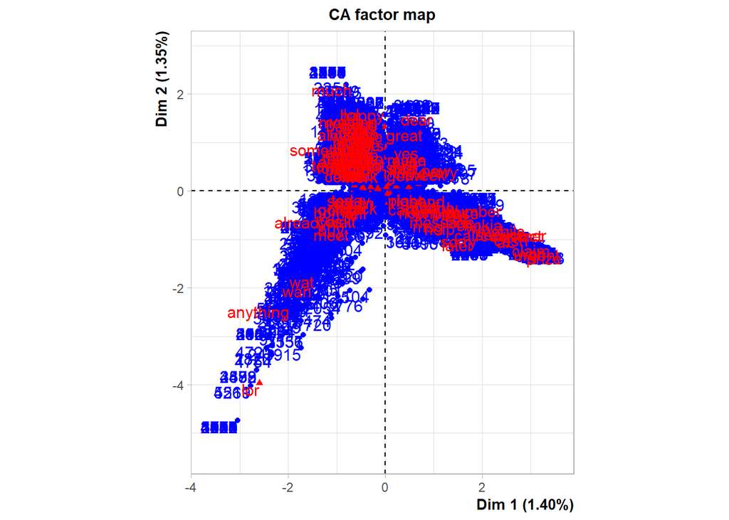

```r
#AFC sur spam_mat
res.ca.spam = CA(spam.m, axes = c(1,2))
```

### Autres affichages

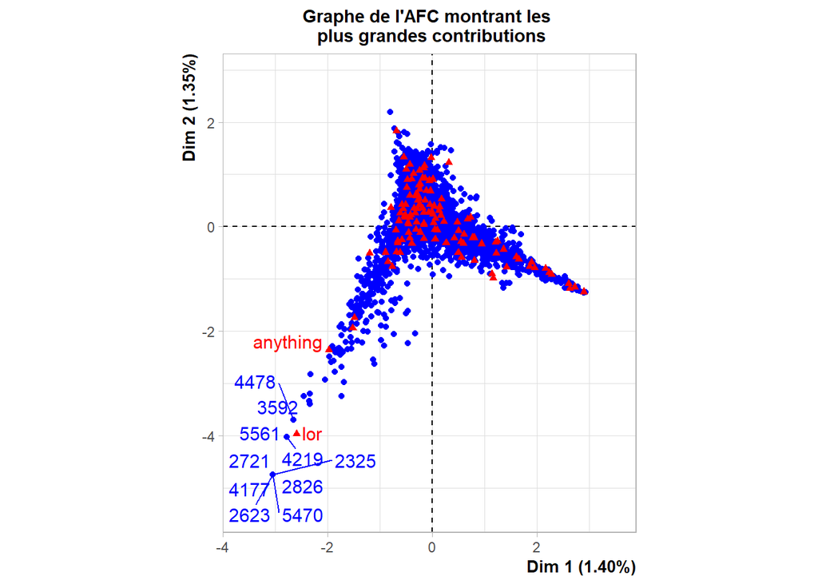

```r
plot.CA(res.ca.spam, selectCol='contrib 2', selectRow='contrib 10',
        unselect=0, title="Graphe de l'AFC montrant les \n plus grandes contributions")
```

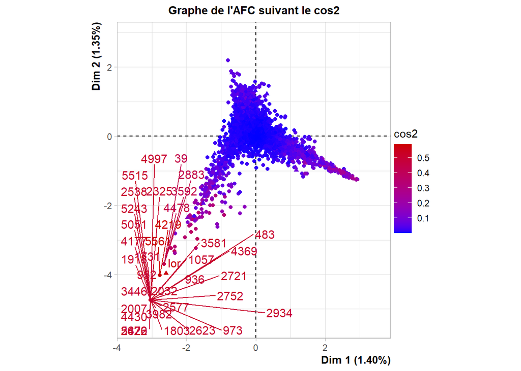

```r
plot.CA(res.ca.spam,selectCol='cos2 0.4',selectRow='cos2 0.4',
        title="Graphe de l'AFC suivant le cos2",
        habillage='cos2')
```

Remarquons les valeurs rouge ayant un cos2 plus proche de 1 contribue le plus a la creation de l’axe (tout comme dans le graphe précédent).

### Tableaux des contributions et qualités de représentation (cos2)

```r
res.ca.spam$col$contrib[1:10,1:2]
```

```
##                Dim 1       Dim 2
## got     3.640464e-01 0.065917078
## great   6.555061e-05 0.986376156
## wat     2.892666e+00 4.147584280
## free    2.164864e+00 0.389338517
## text    5.076121e-01 0.030149377
## txt     1.465464e+00 0.152052682
## win     1.261631e+00 0.186468481
## already 1.442850e+00 0.273115894
## say     4.305781e-01 0.003746362
## around  9.245536e-02 0.095857043
```

```r
res.ca.spam$col$cos2[1:10,1:2]
```

```
##                Dim 1        Dim 2
## got     5.741010e-03 9.981371e-04
## great   1.012678e-06 1.463181e-02
## wat     3.762668e-02 5.180284e-02
## free    4.917974e-02 8.492659e-03
## text    8.902966e-03 5.077406e-04
## txt     4.342185e-02 4.326016e-03
## win     2.756257e-02 3.911593e-03
## already 1.880489e-02 3.417884e-03
## say     7.204789e-03 6.019215e-05
## around  1.457752e-03 1.451231e-03
```

## **(2) Application un algorithme de classification approprié : skmeans**

Nous cette partie nous avons choisi d’appliquer l’algorithme skmeans, car il correspond parfaitement à la classification Documents-Termes (données directionnelles).

- **Application de l’algorithme skmeans avec 2 classes**

```r
# skmeans
set.seed(42)
spam.clust2 = skmeans(spam.m, 2)
#récuperer les predicted labels pour skmeans à 2 classes
predicted.labels.clust2 = spam.clust2$cluster
```

**- construction de la matrice de confusion sur la base de la variable spam**

```r
#confusionMatrix
cm = table(predicted.labels.clust2, true.labels)
lin_assignement = solve_LSAP(cm, maximum=TRUE) # réalise algorithme hongrois
# pour obtenir une matrice qui maximise les valeurs diagonales
cm = table(lin_assignement[predicted.labels.clust2], true.labels)
print(cm)
```

```
##    true.labels
##        1    2
##   1 3289   64
##   2  706  666
```

**- Visualisation des clusters**

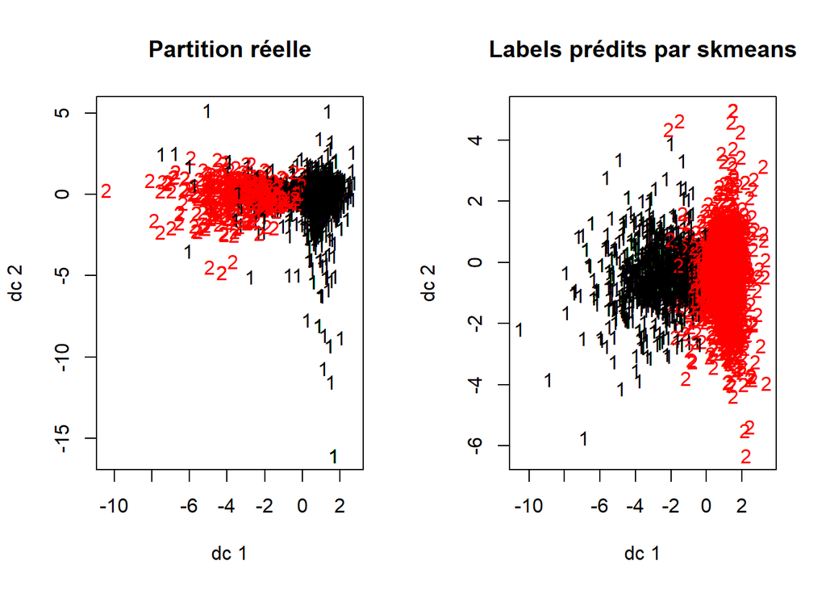

```r
par(mfrow=c(1,2))
plotcluster(spam.m, true.labels, main='Partition réelle')
plotcluster(spam.m, predicted.labels.clust2, main='Labels prédits par skmeans')
```

**- Calculer le taux d’accuracy, NMI et ARI**

```r
#accuracy
accuracy <- sum(diag(cm))/length(true.labels)
print(accuracy)
```

```
## [1] 0.837037
```

```r
#NMI

nmi <- NMI(predicted.labels.clust2, true.labels)
print(nmi)
```

```
## [1] 0.2693019
```

```r
#ARI
ari <- ARI(predicted.labels.clust2, true.labels)
print(ari)
```

```
## [1] 0.4043253
```

Les résultats ne sont pas très bon notamment à cause de la réduction de tableau que nous avons fait au tout début.

## **(3) Skmeans à 3 classes**

```r
# skmeans
set.seed(42)
spam.clust3 = skmeans(spam.m,3)
#récuperer les predicted labels
predicted.labels.clust3 = spam.clust3$cluster

#table de confusion
cm2 = table(predicted.labels.clust3, true.labels)
print(cm2)
```

```
##                        true.labels
## predicted.labels.clust3    1    2
##                       1 2051   53
##                       2  583  640
##                       3 1361   37
```

**- Visualiser les résultats**

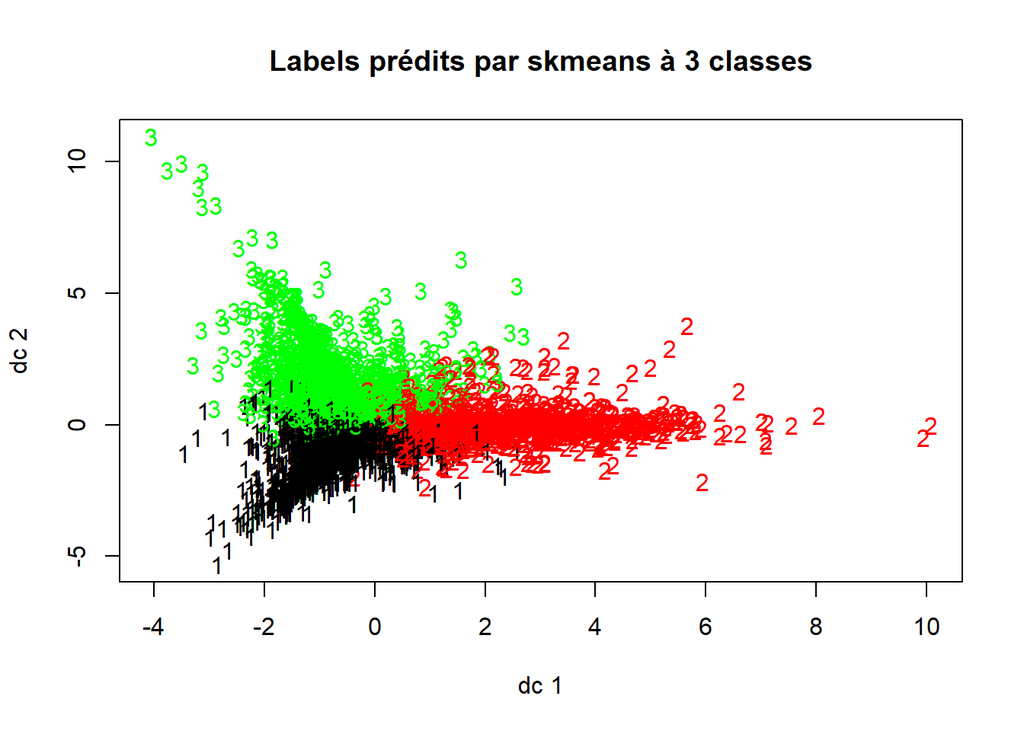

```r
plotcluster(spam.m, predicted.labels.clust3, main='Labels prédits par skmeans à 3 classes')
```

En appliquant l’algorithme skmeans avec nombre de clusters égale à 3, nous remarquons qu’il existe des mails qui n’ont pas pu être classés dans les deux classes *spam* et *ham* et que ses derniers semblent aussi formé un cluster distinct.

**NOTE IMPORTANTE** Nous avions initialiser notre matrice avec une pondération tf-idf, une réexécution avec une pondération "classique (code-ci dessous) nous donne des résultats et des interprétations similaires dans les questions précédentes.

```r
mdt <- DocumentTermMatrix(mails, control=list())
```

## **(4) Appliquer un co-clustering approprié**

### Coclust

```r
#choix du packages à utiliser, (coclust)
clust <- CoClust(spam.m, dimset = 2:4, noc=2, copula="frank",
                 method.ma="empirical", method.c="ml",writeout=1)
#save
saveRDS(clust,"./clust")
```

L’execution de cette fonction ne fonctionne pas et nous rencontrons des messages comme : *Hessian matrix not invertible* ou *possible convergence problem* qui doivent être due à la spartité du problème.

### Blockcluster

```r
coclust.spam = coclusterContingency(spam.m, nbcocluster=c(2,2))
```

```
## Co-Clustering successfully terminated!
```

```r
coclust.spam@rowclass[1:100]
```

```
##   [1] 0 0 0 0 0 0 0 0 0 0 0 0 0 0 0 0 0 0 0 0 0 0 0 0 0 0 0 0 0 0 0 0 0 0 0 0 0
##  [38] 0 0 0 0 0 0 0 0 0 0 0 0 0 0 0 1 0 0 0 0 0 0 0 0 0 0 0 0 1 0 0 0 0 0 1 1 1
##  [75] 0 0 0 0 0 0 0 0 0 0 0 0 0 0 0 0 0 0 0 0 0 0 0 0 0 0
```

```r
# changement de valeurs pour fit avec les true.labels
predicted.spam.m = coclust.spam@rowclass
predicted.spam.m[predicted.spam.m == 1] <-2
predicted.spam.m[predicted.spam.m == 0] <-1
```

## **(5) Visualiser ces classes à l’aide de méthodes de réduction de dimension**

Nous avions appliquer depuis le début une pondération tf-idf (nous répondrons à la question 6)

Visualisons les classes obtenues à l’aide de réductions de dimensions

### Visualisation grace à t-SNE

La fonction suivante nous permettra de visualiser :

```r
plot_tsne <- function (tsne, predicted.classes, true.classes){
  par(mfrow=c(1,2))
  plot(tsne$Y,
       col=predicted.classes,
       xlab="1ere composante",
       ylab="2eme composante",
       cex.main = 0.9,
       cex.lab = 0.9,
       main="Classes prédites sur le plan produit par t-SNE")
  plot(tsne$Y,
       col=true.classes,
       xlab="1ere composante",
       ylab="2eme composante",
       cex.main = 0.9,
       cex.lab = 0.9,
       main="Vraies classes sur le plan produit par t-SNE")
}
```

```r
tsne.spam.m=Rtsne(spam.m, dim=2, perplexity=50, check_duplicates = FALSE)
```

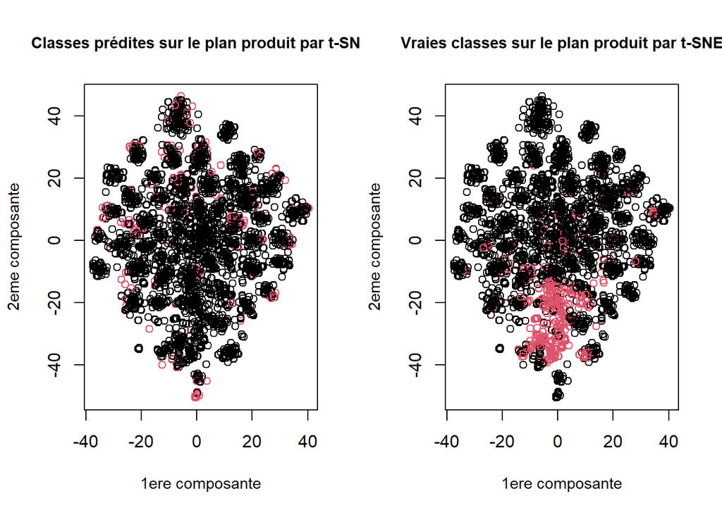

```r
plot_tsne(tsne.spam.m, predicted.spam.m, true.labels)
```

### Visualisation sur le premier plan factoriel de l’ACP

```r
pca.spam.m = PCA(spam.m, graph=FALSE)
```

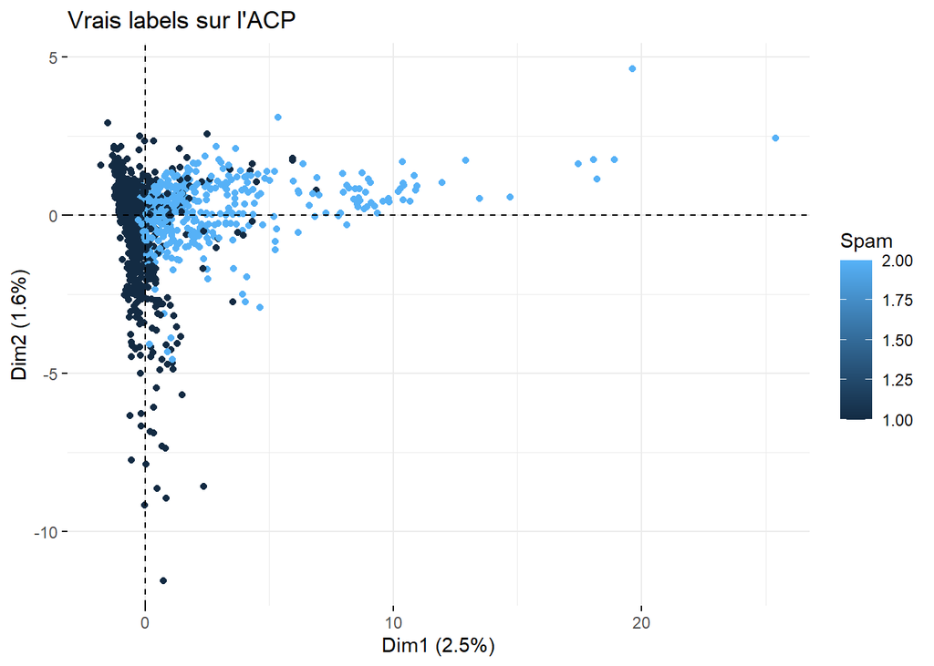

```r
fviz_pca_ind(pca.spam.m,
             geom.ind = "point",
             col.ind = true.labels, # colorer by groups
             legend.title = "Spam",
             title = 'Vrais labels sur l\'ACP')
```

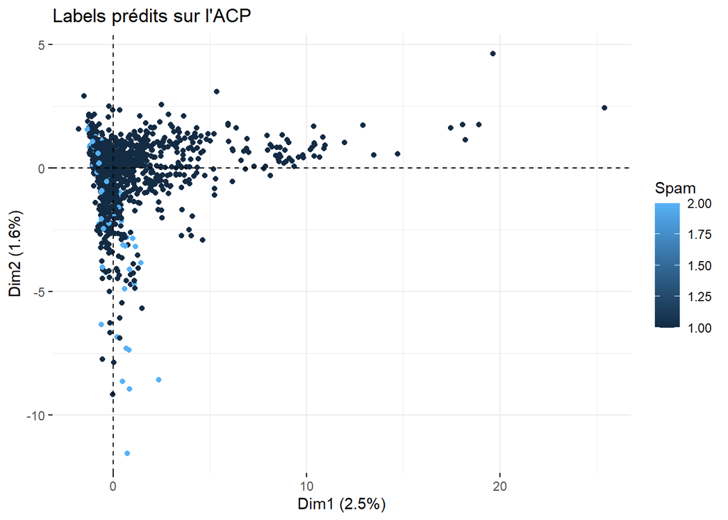

```r
fviz_pca_ind(pca.spam.m,
             geom.ind = "point",
             col.ind = predicted.spam.m,
             legend.title = "Spam",
             title = 'Labels prédits sur l\'ACP')
```

## **(6) Même étape avec une autre pondération**

Appliquons une autre pondération :

```r
#matrix Document_Term
mdt <- DocumentTermMatrix(mails, control=list())
```

```r
#delete 99% of sparse data
mdt = removeSparseTerms(mdt, 0.99)

spam_m <- as.matrix(mdt)
print(dim(spam_m))
```

```
## [1] 5572  121
```

```r
# convert ham  et spam to 1 and 2 respectively
spam$v1[spam$v1 == 'ham'] = 1
spam$v1[spam$v1 == 'spam'] = 2

# index of lines when somme(lines) ==0
lines <- unique(which(rowSums(spam_m) == 0, arr.ind = FALSE)) #get 0 rows
length(lines)
```

```
## [1] 847
```

```r
#delete lines according to index obtained above
true.labels = as.numeric(spam$v1[-lines])
spam.m2 = spam_m[-lines,]
dim(spam.m2)
```

```
## [1] 4725  121
```

### Visualisation grace à t-SNE

```r
tsne.spam.m2=Rtsne(spam.m2, dim=2, perplexity=50, check_duplicates = FALSE)
```

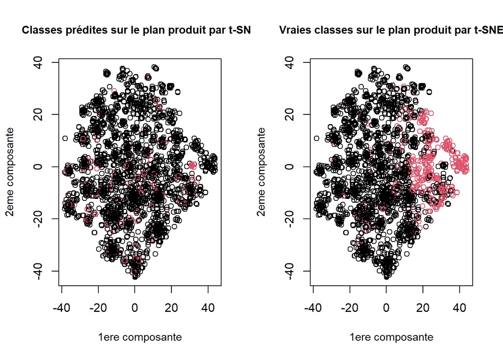

```r
plot_tsne(tsne.spam.m2, predicted.spam.m, true.labels)
```

### Visualisation sur le premier plan factoriel de l’ACP

```r
pca.spam.m2 = PCA(spam.m2, graph=FALSE)
```

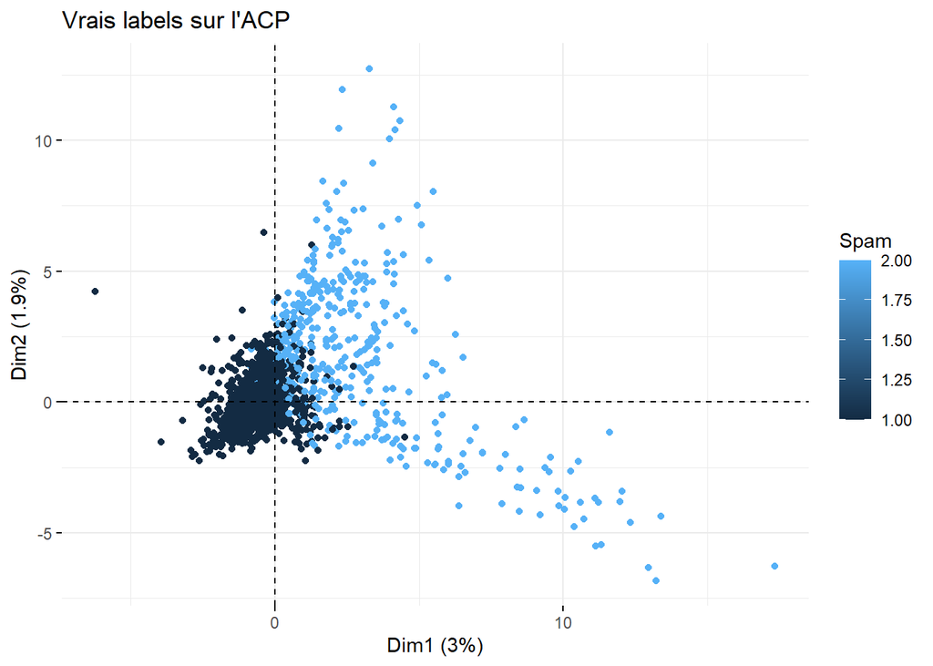

```r
fviz_pca_ind(pca.spam.m2,
             geom.ind = "point",
             col.ind = true.labels, # colorer by groups
             legend.title = "Spam",
             title = 'Vrais labels sur l\'ACP')
```

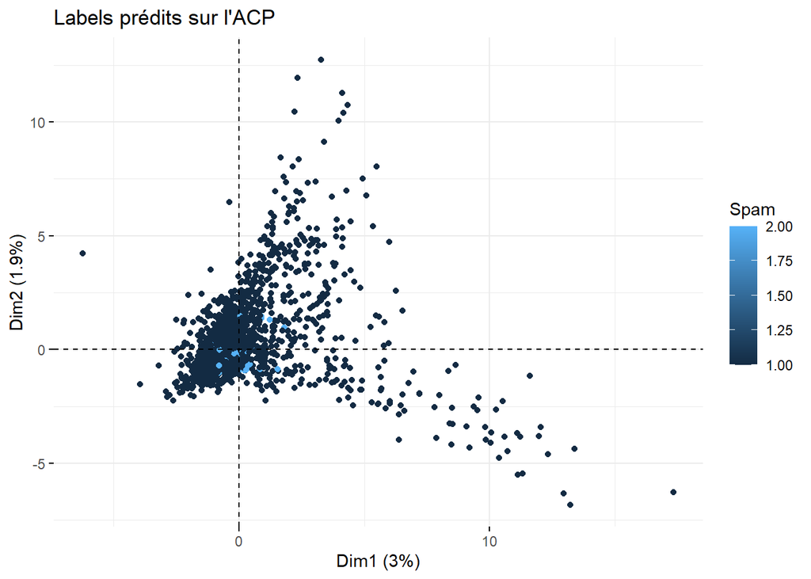

```r
fviz_pca_ind(pca.spam.m2,
             geom.ind = "point",
             col.ind = predicted.spam.m,
             legend.title = "Spam",
             title = 'Labels prédits sur l\'ACP')
```

## **(7) Appliquer le modèle de von-Mises Fischer**

```r
vMF_model <- lapply(1:2, function(K) movMF(spam.m, k = K, control= list(E = "hardmax", nruns = 10))) #hardmax pour choisir l'algo EM
#The BIC values for the different mixtures can be compared using
sapply(vMF_model, BIC)
```

```
## [1] -15631.55 -25705.37
```

Dans ce qui suit, nous examinons les 10 mots les plus importants de chaque classe 1 et 2 correspondants aux classes ham et spam respectivement.

```r
model = movMF(spam.m, 2, control = list(E = "hardmax", maxiter = 5))
apply(coef(model)$theta, 1, function(x) colnames(coef(model)$theta)[order(x, decreasing = TRUE)[1:10]])
```

```
##       1       2
##  [1,] "can"   "call"
##  [2,] "ltgt"  "just"
##  [3,] "like"  "will"
##  [4,] "got"   "get"
##  [5,] "lor"   "good"
##  [6,] "going" "know"
##  [7,] "now"   "now"
##  [8,] "home"  "å£"
##  [9,] "still" "free"
## [10,] "one"   "come"
```